# R Notebook

# Define the Question

## Specifying the Question

Which individuals are most likely to click on her ads?

## Defining the Metric for Success

Identify which individuals are most likely to click on her ads

## Understanding the context

A Kenyan entrepreneur has created an online cryptography course and would want to advertise it on her blog. She currently targets audiences originating from various countries.

## Recording the Experimental Design

1. Load , read and explore the dataset.
2. Clean the dataset.
3. Perform Exploratory Data Analysis.
   - Univariate Analysis
   - Bivariate Analysis

## Data Relevance

This dataset is really usefull it contains details about the users that visit her blog.

# Dataset

```r
library(lubridate, warn.conflicts = FALSE)
```

```r
df<- read.csv('C:/Users/Admin/Downloads/advertising.csv')
df1 <- df
head(df)
```

|  | Daily.Time.Spent.on.Site | Age | Area.Income | Daily.Internet.Usage | Ad.Topic.Line | City | Male | Country | Timestamp | Clicked.on.Ad |
| --- | --- | --- | --- | --- | --- | --- | --- | --- | --- | --- |
| 1 | 68.95 | 35 | 61833.90 | 256.09 | Cloned 5thgeneration orchestration | Wrightburgh | 0 | Tunisia | 2016-03-27 00:53:11 | 0 |
| 2 | 80.23 | 31 | 68441.85 | 193.77 | Monitored national standardization | West Jodi | 1 | Nauru | 2016-04-04 01:39:02 | 0 |
| 3 | 69.47 | 26 | 59785.94 | 236.50 | Organic bottom-line service-desk | Davidton | 0 | San Marino | 2016-03-13 20:35:42 | 0 |
| 4 | 74.15 | 29 | 54806.18 | 245.89 | Triple-buffered reciprocal time-frame | West Terrifurt | 1 | Italy | 2016-01-10 02:31:19 | 0 |
| 5 | 68.37 | 35 | 73889.99 | 225.58 | Robust logistical utilization | South Manuel | 0 | Iceland | 2016-06-03 03:36:18 | 0 |
| 6 | 59.99 | 23 | 59761.56 | 226.74 | Sharable client-driven software | Jamieberg | 1 | Norway | 2016-05-19 14:30:17 | 0 |

## Number of columns

```r
ncol(df)
```

```
## [1] 10
```

## number of rows

```r
nrow(df)
```

```
## [1] 1000
```

## A summary of the datasets

```r
summary(df)
```

```
##  Daily.Time.Spent.on.Site      Age         Area.Income    Daily.Internet.Usage
##  Min.   :32.60            Min.   :19.00   Min.   :13996   Min.   :104.8
##  1st Qu.:51.36            1st Qu.:29.00   1st Qu.:47032   1st Qu.:138.8
##  Median :68.22            Median :35.00   Median :57012   Median :183.1
##  Mean   :65.00            Mean   :36.01   Mean   :55000   Mean   :180.0
##  3rd Qu.:78.55            3rd Qu.:42.00   3rd Qu.:65471   3rd Qu.:218.8
##  Max.   :91.43            Max.   :61.00   Max.   :79485   Max.   :270.0
##  Ad.Topic.Line          City                Male         Country
##  Length:1000        Length:1000        Min.   :0.000   Length:1000
##  Class :character   Class :character   1st Qu.:0.000   Class :character
##  Mode  :character   Mode  :character   Median :0.000   Mode  :character
##                                        Mean   :0.481
##                                        3rd Qu.:1.000
##                                        Max.   :1.000
##   Timestamp         Clicked.on.Ad
##  Length:1000        Min.   :0.0
##  Class :character   1st Qu.:0.0
##  Mode  :character   Median :0.5
##                     Mean   :0.5
##                     3rd Qu.:1.0
##                     Max.   :1.0
```

## Top six records in dataset

```r
head(df)
```

|  | Daily.Time.Spent.on.Site | Age | Area.Income | Daily.Internet.Usage | Ad.Topic.Line | City | Male | Country | Timestamp | Clicked.on.Ad |
| --- | --- | --- | --- | --- | --- | --- | --- | --- | --- | --- |
| 1 | 68.95 | 35 | 61833.90 | 256.09 | Cloned 5thgeneration orchestration | Wrightburgh | 0 | Tunisia | 2016-03-27 00:53:11 | 0 |
| 2 | 80.23 | 31 | 68441.85 | 193.77 | Monitored national standardization | West Jodi | 1 | Nauru | 2016-04-04 01:39:02 | 0 |
| 3 | 69.47 | 26 | 59785.94 | 236.50 | Organic bottom-line service-desk | Davidton | 0 | San Marino | 2016-03-13 20:35:42 | 0 |
| 4 | 74.15 | 29 | 54806.18 | 245.89 | Triple-buffered reciprocal time-frame | West Terrifurt | 1 | Italy | 2016-01-10 02:31:19 | 0 |
| 5 | 68.37 | 35 | 73889.99 | 225.58 | Robust logistical utilization | South Manuel | 0 | Iceland | 2016-06-03 03:36:18 | 0 |
| 6 | 59.99 | 23 | 59761.56 | 226.74 | Sharable client-driven software | Jamieberg | 1 | Norway | 2016-05-19 14:30:17 | 0 |

## Bottom six records in the dataset

```r
tail(df)
```

|  | Daily.Time.Spent.on.Site | Age | Area.Income | Daily.Internet.Usage | Ad.Topic.Line | City | Male | Country | Timestamp | Clicked.on.Ad |
| --- | --- | --- | --- | --- | --- | --- | --- | --- | --- | --- |
| 995 | 43.70 | 28 | 63126.96 | 173.01 | Front-line bifurcated ability | Nicholasland | 0 | Mayotte | 2016-04-04 03:57:48 | 1 |
| 996 | 72.97 | 30 | 71384.57 | 208.58 | Fundamental modular algorithm | Duffystad | 1 | Lebanon | 2016-02-11 21:49:00 | 1 |
| 997 | 51.30 | 45 | 67782.17 | 134.42 | Grass-roots cohesive monitoring | New Darlene | 1 | Bosnia and Herzegovina | 2016-04-22 02:07:01 | 1 |
| 998 | 51.63 | 51 | 42415.72 | 120.37 | Expanded intangible solution | South Jessica | 1 | Mongolia | 2016-02-01 17:24:57 | 1 |
| 999 | 55.55 | 19 | 41920.79 | 187.95 | Proactive bandwidth-monitored policy | West Steven | 0 | Guatemala | 2016-03-24 02:35:54 | 0 |
| 1000 | 45.01 | 26 | 29875.80 | 178.35 | Virtual 5thgeneration emulation | Ronniemouth | 0 | Brazil | 2016-06-03 21:43:21 | 1 |

```r
colnames(df)
```

```
##  [1] "Daily.Time.Spent.on.Site" "Age"
##  [3] "Area.Income"              "Daily.Internet.Usage"
##  [5] "Ad.Topic.Line"            "City"
##  [7] "Male"                     "Country"
##  [9] "Timestamp"                "Clicked.on.Ad"
```

# Data Cleaning

## Duplicate

```r
duplicated_rows <- df[duplicated(df),]
nrow(duplicated_rows)
```

```
## [1] 0
```

```r
nrow(df)
```

```
## [1] 1000
```

```r
df <- df[!duplicated(df), ]
nrow(df)
```

```
## [1] 1000
```

We didn’t encounter any duplicate records in our dataset.

## Missing Values

```r
colSums(is.na(df))
```

```
## Daily.Time.Spent.on.Site                      Age              Area.Income
##                        0                        0                        0
##     Daily.Internet.Usage            Ad.Topic.Line                     City
##                        0                        0                        0
##                     Male                  Country                Timestamp
##                        0                        0                        0
##            Clicked.on.Ad
##                        0
```

## Outliers

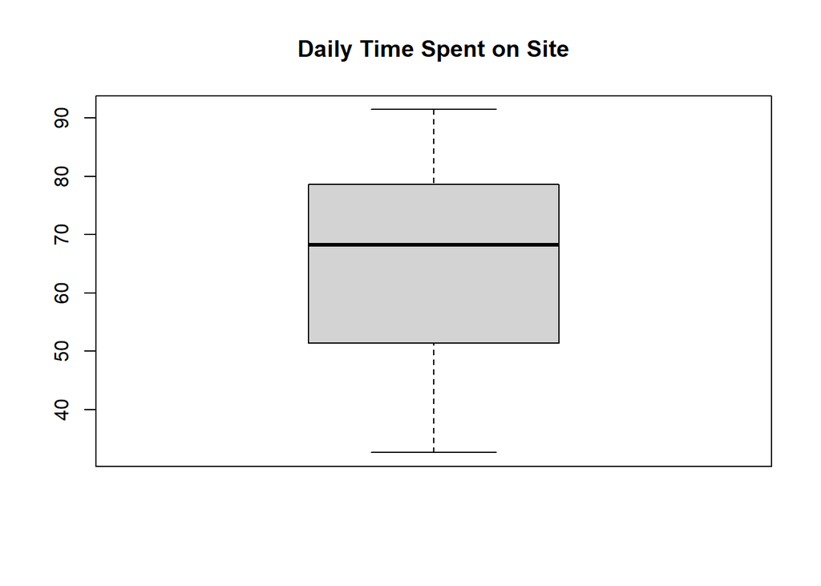

```r
boxplot(df$Daily.Time.Spent.on.Site, main = "Daily Time Spent on Site")
```

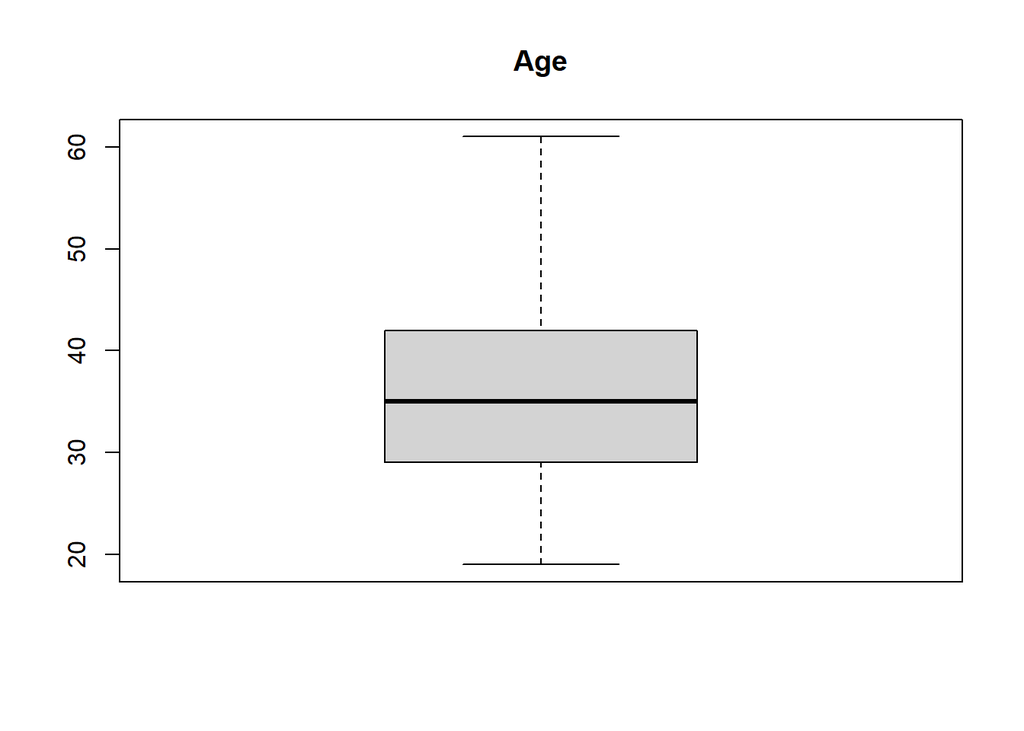

```r
boxplot(df$Age, main = 'Age')
```

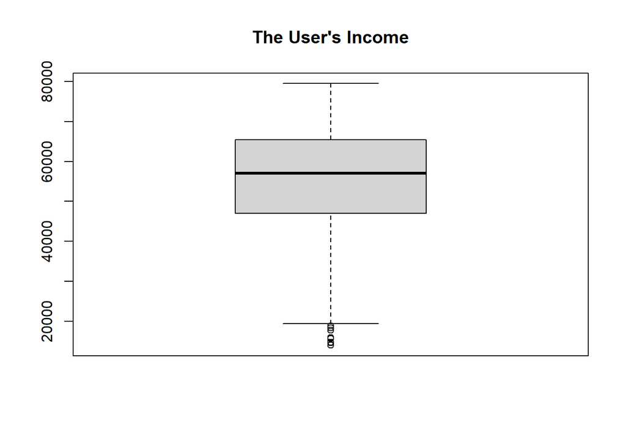

```r
boxplot(df$Area.Income, main = 'The User\'s Income')
```

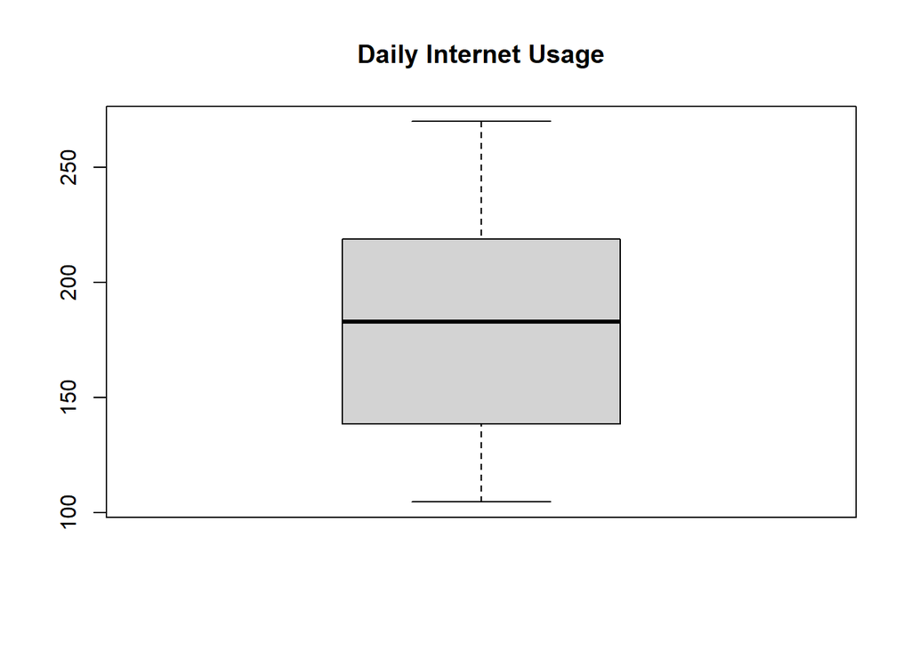

```r
boxplot(df$Daily.Internet.Usage, main = 'Daily Internet Usage')
```

### This are the are outliers in the column Area.Income

```r
boxplot.stats(df$Area.Income)$out
```

```
## [1] 17709.98 18819.34 15598.29 15879.10 14548.06 13996.50 14775.50 18368.57
```

## Changing Timestamp column from a character column to a datetime column

```r
df$Timestamp <- ymd_hms(df$Timestamp)
```

## Changing the column name

```r
names(df)[names(df) == "Male"] <- "Gender"
colnames(df)
```

```
##  [1] "Daily.Time.Spent.on.Site" "Age"
##  [3] "Area.Income"              "Daily.Internet.Usage"
##  [5] "Ad.Topic.Line"            "City"
##  [7] "Gender"                   "Country"
##  [9] "Timestamp"                "Clicked.on.Ad"
```

## Changing the values from numbers to charaters

```r
df$Gender <- as.character(df$Gender)
df$Gender[df$Gender == "0"] <- "Female"
df$Gender[df$Gender == "1"] <- "Male"
unique(df$Gender)
```

```
## [1] "Female" "Male"
```

```r
df$Clicked.on.Ad <- as.character(df$Clicked.on.Ad)
df$Clicked.on.Ad[df$Clicked.on.Ad == "0"] <- "No"
df$Clicked.on.Ad[df$Clicked.on.Ad == "1"] <- "Yes"
unique(df$Clicked.on.Ad)
```

```
## [1] "No"  "Yes"
```

```r
#install.packages("devtools")

#devtools::install_github("tidyverse/lubridate")
```

```r
#library(lubridate, warn.conflicts = FALSE)
```

## Adding new column:

### month

```r
df$month <- month(df$Timestamp, label = TRUE)
df$month <- as.character(df$month)
unique(df$month)
```

```
## [1] "Mar" "Apr" "Jan" "Jun" "May" "Jul" "Feb"
```

### hour

```r
df$hour <- hour(df$Timestamp)
hours <- unique(df$hour)
sort(hours)
```

```
##  [1]  0  1  2  3  4  5  6  7  8  9 10 11 12 13 14 15 16 17 18 19 20 21 22 23
```

### Day of the week

```r
df$day.of.the.week <- wday(df$Timestamp, label = TRUE)
unique(df$day.of.the.week)
```

```
## [1] Sun Mon Fri Thu Wed Sat Tue
## Levels: Sun < Mon < Tue < Wed < Thu < Fri < Sat
```

### date

```r
df$date <- date(df$Timestamp)
```

## Univariate Analysis

### Mean

#### Daily.Time.Spent.on.Site

```r
Daily_Time_1 <- mean(df$Daily.Time.Spent.on.Site[df$Clicked.on.Ad=="Yes"])
Daily_Time_1
```

```
## [1] 53.14578
```

#### Age

```r
Age_3 <- mean(df$Age[df$Clicked.on.Ad=="Yes"])
Age_3
```

```
## [1] 40.334
```

#### Area.Income

```r
area_income_2 <- mean(df$Area.Income[df$Clicked.on.Ad=="Yes"])
area_income_2
```

```
## [1] 48614.41
```

#### Daily.Internet.Usage

```r
Usage_2 <- mean(df$Daily.Internet.Usage[df$Clicked.on.Ad=="Yes"])
Usage_2
```

```
## [1] 145.4865
```

### Median

#### Daily.Time.Spent.on.Site

```r
Daily_Time <- median(df$Daily.Time.Spent.on.Site[df$Clicked.on.Ad=="Yes"])
Daily_Time
```

```
## [1] 51.53
```

#### Age

```r
Age_2 <- median(df$Age[df$Clicked.on.Ad=="Yes"])
Age_2
```

```
## [1] 40
```

#### Area.Income

```r
area_income_2 <- median(df$Area.Income[df$Clicked.on.Ad=="Yes"])
area_income_2
```

```
## [1] 49417.26
```

#### Daily.Internet.Usage

```r
Usage_1 <- median(df$Daily.Internet.Usage[df$Clicked.on.Ad=="Yes"])
Usage_1
```

```
## [1] 138.79
```

### Mode

```r
getmode <- function(v) {
   uniqv <- unique(v)
   uniqv[which.max(tabulate(match(v, uniqv)))]
}
```

#### Age

```r
age_1 <- getmode(df$Age[df$Clicked.on.Ad=="Yes"])
print(age_1)
```

```
## [1] 45
```

#### Daily.Time.Spent.on.Site

```r
time_spent <- getmode(df$Daily.Time.Spent.on.Site[df$Clicked.on.Ad=="Yes"])
print(time_spent)
```

```
## [1] 75.55
```

#### Area.Income

```r
Income_1 <- getmode(df$Area.Income[df$Clicked.on.Ad=="Yes"])
print(Income_1)
```

```
## [1] 24593.33
```

#### Daily.Internet.Usage

```r
internet_usage <- getmode(df$Daily.Internet.Usage[df$Clicked.on.Ad=="Yes"])
print(internet_usage)
```

```
## [1] 167.22
```

#### Ad.Topic.Line

```r
topic_1 <- getmode(df$Ad.Topic.Line[df$Clicked.on.Ad=="Yes"])
print(topic_1)
```

```
## [1] "Reactive local challenge"
```

#### City

```r
city_1 <- getmode(df$City[df$Clicked.on.Ad=="Yes"])
print(city_1)
```

```
## [1] "Robertfurt"
```

#### Country

```r
country_1 <- getmode(df$Country[df$Clicked.on.Ad=="Yes"])
print(country_1)
```

```
## [1] "Australia"
```

#### Gender

```r
gender_1 <- getmode(df$Gender[df$Clicked.on.Ad=="Yes"])
print(gender_1)
```

```
## [1] "Female"
```

#### Clicked.on.Ad

```r
clicked_1 <- getmode(df$Clicked.on.Ad)
print(clicked_1)
```

```
## [1] "No"
```

#### month

```r
month_1 <- getmode(df$month[df$Clicked.on.Ad=="Yes"])
print(month_1)
```

```
## [1] "Feb"
```

#### day.of.the.week

```r
day_of_the_week <- getmode(df$day.of.the.week[df$Clicked.on.Ad=="Yes"])
print(day_of_the_week)
```

```
## [1] Sun
## Levels: Sun < Mon < Tue < Wed < Thu < Fri < Sat
```

#### hour

```r
hour_1 <- getmode(df$hour[df$Clicked.on.Ad=="Yes"])
print(hour_1)
```

```
## [1] 9
```

#### month

```r
result <- getmode(df$month[df$Clicked.on.Ad=="Yes"])
print(result)
```

```
## [1] "Feb"
```

### Maximum

#### Area.Income

```r
Income_2 <- max(df$Area.Income[df$Clicked.on.Ad=="Yes"])
print(Income_2)
```

```
## [1] 78520.99
```

#### Daily.Internet.Usage

```r
Usage_2 <- max(df$Daily.Internet.Usage[df$Clicked.on.Ad=="Yes"])
Usage_2
```

```
## [1] 269.96
```

#### Daily.Time.Spent.on.Site

```r
time_spent_1 <- max(df$Daily.Time.Spent.on.Site[df$Clicked.on.Ad=="Yes"])
print(time_spent_1)
```

```
## [1] 91.37
```

#### Age

```r
a_g_e <- max(df$Age[df$Clicked.on.Ad=="Yes"])
print(a_g_e)
```

```
## [1] 61
```

### Minimum

#### Area.Income

```r
Income_3 <- min(df$Area.Income[df$Clicked.on.Ad=="Yes"])
print(Income_3)
```

```
## [1] 13996.5
```

#### Daily.Internet.Usage

```r
Usage_3 <- min(df$Daily.Internet.Usage[df$Clicked.on.Ad=="Yes"])
Usage_3
```

```
## [1] 104.78
```

#### Daily.Time.Spent.on.Site

```r
time_spent_2 <- min(df$Daily.Time.Spent.on.Site[df$Clicked.on.Ad=="Yes"])
print(time_spent_2)
```

```
## [1] 32.6
```

#### Age

```r
a_g_e_1 <- min(df$Age[df$Clicked.on.Ad=="Yes"])
print(a_g_e_1)
```

```
## [1] 19
```

### Range

#### Area.Income

```r
Income_2 <- range(df$Area.Income[df$Clicked.on.Ad=="Yes"])
print(Income_2)
```

```
## [1] 13996.50 78520.99
```

#### Daily.Internet.Usage

```r
Usage_2 <- range(df$Daily.Internet.Usage[df$Clicked.on.Ad=="Yes"])
Usage_2
```

```
## [1] 104.78 269.96
```

#### Daily.Time.Spent.on.Site

```r
time_spent_1 <- range(df$Daily.Time.Spent.on.Site[df$Clicked.on.Ad=="Yes"])
print(time_spent_1)
```

```
## [1] 32.60 91.37
```

#### Age

```r
a_g_e <- range(df$Age[df$Clicked.on.Ad=="Yes"])
print(a_g_e)
```

```
## [1] 19 61
```

### Quantile

#### Area.Income

```r
Income_2 <- quantile(df$Area.Income[df$Clicked.on.Ad=="Yes"])
print(Income_2)
```

```
##       0%      25%      50%      75%     100%
## 13996.50 39106.62 49417.26 59241.04 78520.99
```

#### Daily.Internet.Usage

```r
Usage_2 <- quantile(df$Daily.Internet.Usage[df$Clicked.on.Ad=="Yes"])
Usage_2
```

```
##       0%      25%      50%      75%     100%
## 104.7800 123.5925 138.7900 161.1600 269.9600
```

#### Daily.Time.Spent.on.Site

```r
time_spent_1 <- quantile(df$Daily.Time.Spent.on.Site[df$Clicked.on.Ad=="Yes"])
print(time_spent_1)
```

```
##      0%     25%     50%     75%    100%
## 32.6000 42.8375 51.5300 62.0750 91.3700
```

#### Age

```r
a_g_e <- quantile(df$Age[df$Clicked.on.Ad=="Yes"])
print(a_g_e)
```

```
##   0%  25%  50%  75% 100%
##   19   34   40   47   61
```

### Variance

#### Area.Income

```r
Income_2 <- var(df$Area.Income[df$Clicked.on.Ad=="Yes"])
print(Income_2)
```

```
## [1] 199268295
```

#### Daily.Internet.Usage

```r
Usage_2 <- var(df$Daily.Internet.Usage[df$Clicked.on.Ad=="Yes"])
Usage_2
```

```
## [1] 901.5502
```

#### Daily.Time.Spent.on.Site

```r
time_spent_1 <- var(df$Daily.Time.Spent.on.Site[df$Clicked.on.Ad=="Yes"])
print(time_spent_1)
```

```
## [1] 164.406
```

#### Age

```r
a_g_e <- var(df$Age[df$Clicked.on.Ad=="Yes"])
print(a_g_e)
```

```
## [1] 78.43932
```

### Standard Deviation

#### Area.Income

```r
Income_2 <- sd(df$Area.Income[df$Clicked.on.Ad=="Yes"])
print(Income_2)
```

```
## [1] 14116.24
```

#### Daily.Internet.Usage

```r
Usage_2 <- sd(df$Daily.Internet.Usage[df$Clicked.on.Ad=="Yes"])
Usage_2
```

```
## [1] 30.02583
```

#### Daily.Time.Spent.on.Site

```r
time_spent_1 <- sd(df$Daily.Time.Spent.on.Site[df$Clicked.on.Ad=="Yes"])
print(time_spent_1)
```

```
## [1] 12.82209
```

#### Age

```r
a_g_e <- sd(df$Age[df$Clicked.on.Ad=="Yes"])
print(a_g_e)
```

```
## [1] 8.856598
```

### Histogram

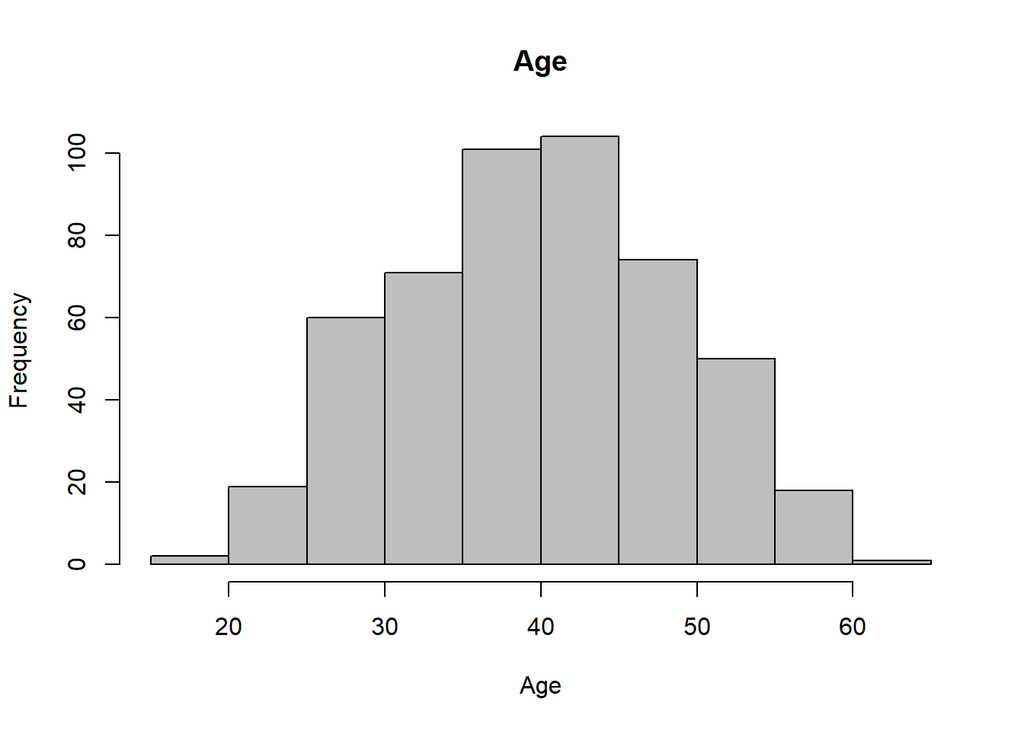

```r
hist_age <- df[df$Clicked.on.Ad == "Yes",]
# Create the histogram.
hist(hist_age$Age, main = "Age", xlab = "Age", col = "grey",border = "black")
```

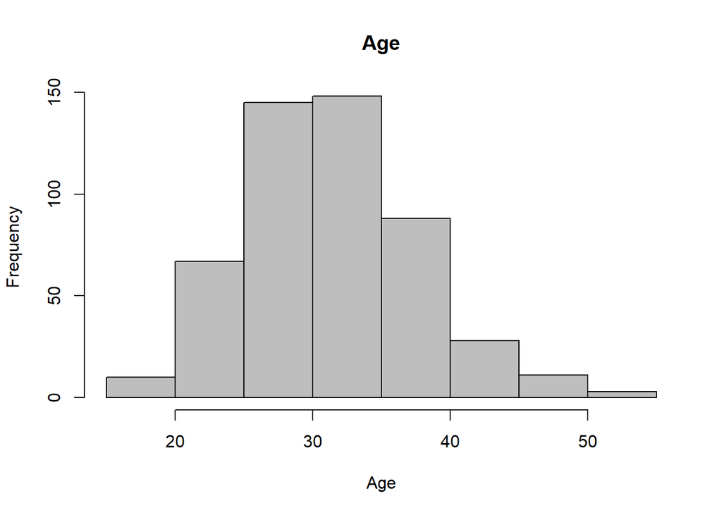

```r
hist_age <- df[df$Clicked.on.Ad == "No",]
# Create the histogram.
hist(hist_age$Age, main = "Age", xlab = "Age", col = "grey",border = "black")
```

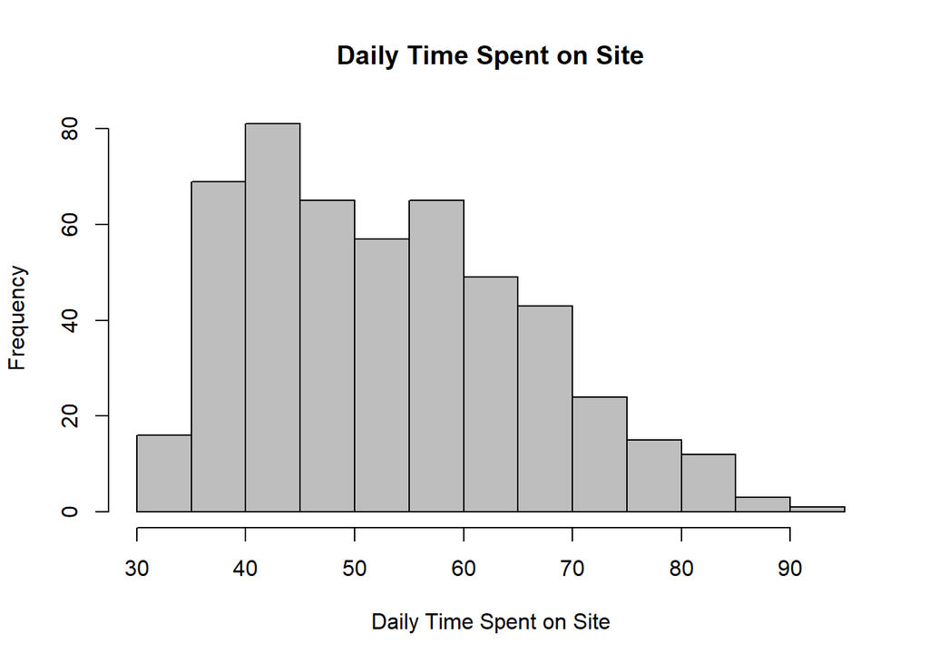

```r
hist_spent <- df[df$Clicked.on.Ad == "Yes",]
# Create the histogram.
hist(hist_spent$Daily.Time.Spent.on.Site, main = "Daily Time Spent on Site",  xlab = "Daily Time Spent on Site",col = "grey",border = "black")
```

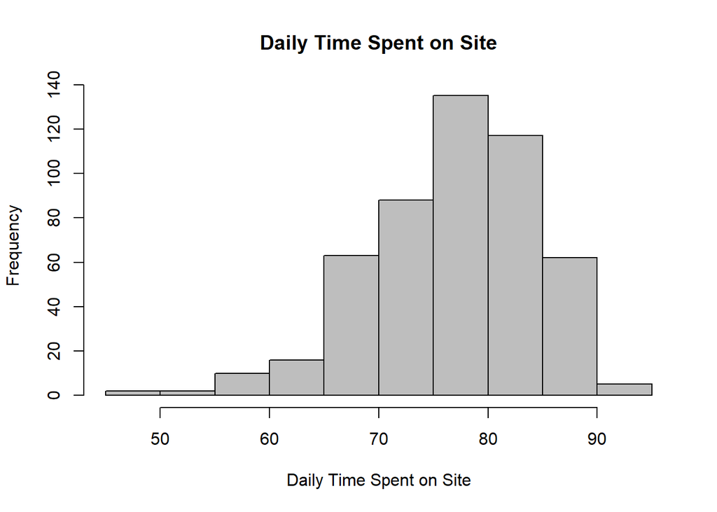

```r
hist_spent <- df[df$Clicked.on.Ad == "No",]
# Create the histogram.
hist(hist_spent$Daily.Time.Spent.on.Site, main = "Daily Time Spent on Site",  xlab = "Daily Time Spent on Site",col = "grey",border = "black")
```

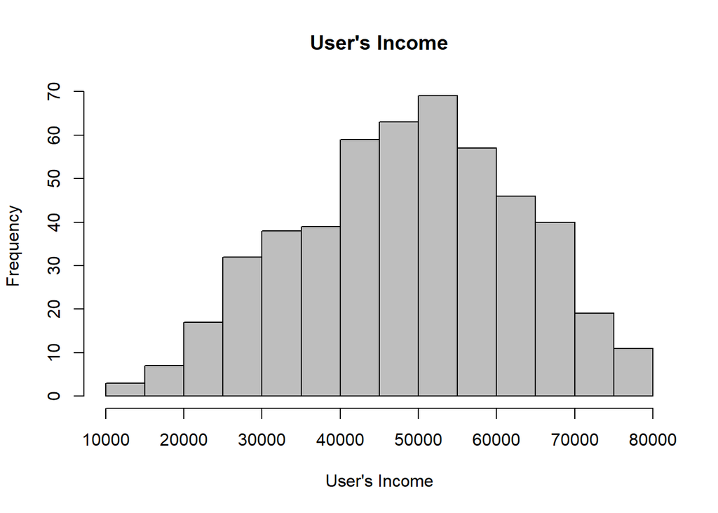

```r
hist_spent <- df[df$Clicked.on.Ad == "Yes",]
# Create the histogram.
hist(hist_spent$Area.Income, main = "User\'s Income",  xlab = "User\'s Income",col = "grey",border = "black")
```

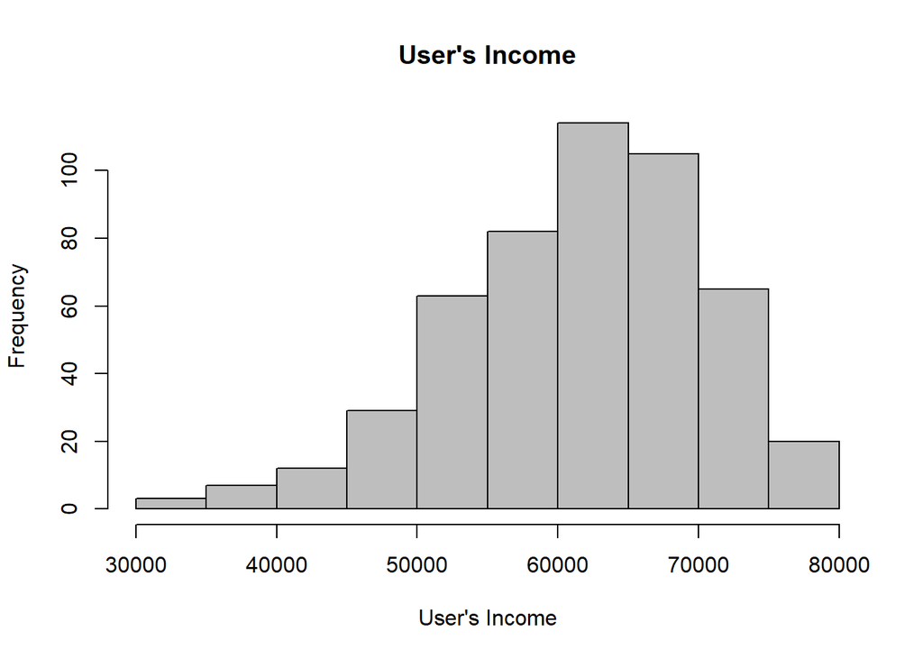

```r
hist_spent <- df[df$Clicked.on.Ad == "No",]
# Create the histogram.
hist(hist_spent$Area.Income, main = "User\'s Income",  xlab = "User\'s Income",col = "grey",border = "black")
```

#### Analyisis: 1. Most people how spent less time on the site click on click of the ad while those how spent more time didn’t click the ad. 2. Those with a income range around 50000 click on the ad while the those that didn’t click most had high salary.

### Bivariate Analyisis

Note: red: represents Yes Blue: represents No

```r
df1
```

[output not shown]

[output cut: 990 more lines]

```r
df1$Timestamp <- ymd_hms(df1$Timestamp)
names(df1)[names(df1) == "Male"] <- "Gender"
names(df1)[names(df1) == "Area.Income"] <- "Income"
names(df1)[names(df1) == "Daily.Internet.Usage"] <- "Usage"
names(df1)[names(df1) == "Daily.Time.Spent.on.Site"] <- "Spent"
df1$month <- month(df1$Timestamp)
df1$hour <- hour(df1$Timestamp)
df1$day.of.the.week <- wday(df1$Timestamp)
cor_df <- df1[, c('day.of.the.week', 'hour', 'month', 'Gender', 'Income', 'Spent', 'Usage', 'Age')]
#cor_df <- lapply(cor_df, as.numeric)
res <- cor(cor_df, cor_df)
round(res, 2)
```

```
##                 day.of.the.week  hour month Gender Income Spent Usage   Age
## day.of.the.week            1.00  0.00 -0.02   0.01   0.00 -0.01 -0.04  0.00
## hour                       0.00  1.00 -0.01   0.06   0.03  0.00  0.07 -0.05
## month                     -0.02 -0.01  1.00   0.01  -0.05 -0.01  0.02  0.02
## Gender                     0.01  0.06  0.01   1.00   0.00 -0.02  0.03 -0.02
## Income                     0.00  0.03 -0.05   0.00   1.00  0.31  0.34 -0.18
## Spent                     -0.01  0.00 -0.01  -0.02   0.31  1.00  0.52 -0.33
## Usage                     -0.04  0.07  0.02   0.03   0.34  0.52  1.00 -0.37
## Age                        0.00 -0.05  0.02  -0.02  -0.18 -0.33 -0.37  1.00
```

[figure not shown]

```r
plot(df1$Spent, df1$Usage, main = "Main title",
     xlab = "X axis title", ylab = "Y axis title",
     pch = 19, frame = FALSE)
```

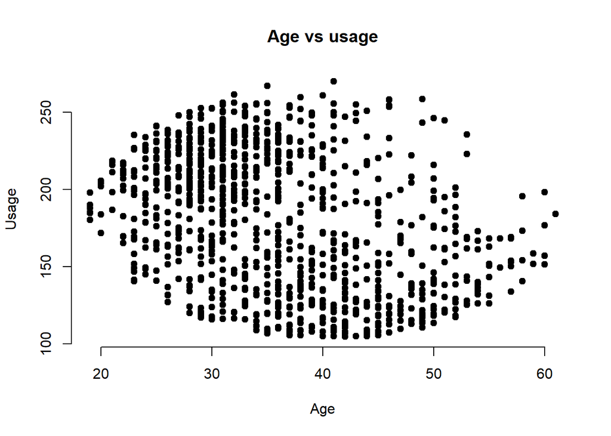

```r
plot(df1$Age, df1$Usage, main = "Age vs usage",
     xlab = "Age", ylab = "Usage",
     pch = 19, frame = FALSE)
```

```r
colnames(df)
```

```
##  [1] "Daily.Time.Spent.on.Site" "Age"
##  [3] "Area.Income"              "Daily.Internet.Usage"
##  [5] "Ad.Topic.Line"            "City"
##  [7] "Gender"                   "Country"
##  [9] "Timestamp"                "Clicked.on.Ad"
## [11] "month"                    "hour"
## [13] "day.of.the.week"          "date"
```

```r
# Alternatively, install just ggplot2:
# install.packages("ggplot2")

# Or the development version from GitHub:
# install.packages("devtools")

#devtools::install_github("tidyverse/ggplot2")
```

```r
library(ggplot2)
```

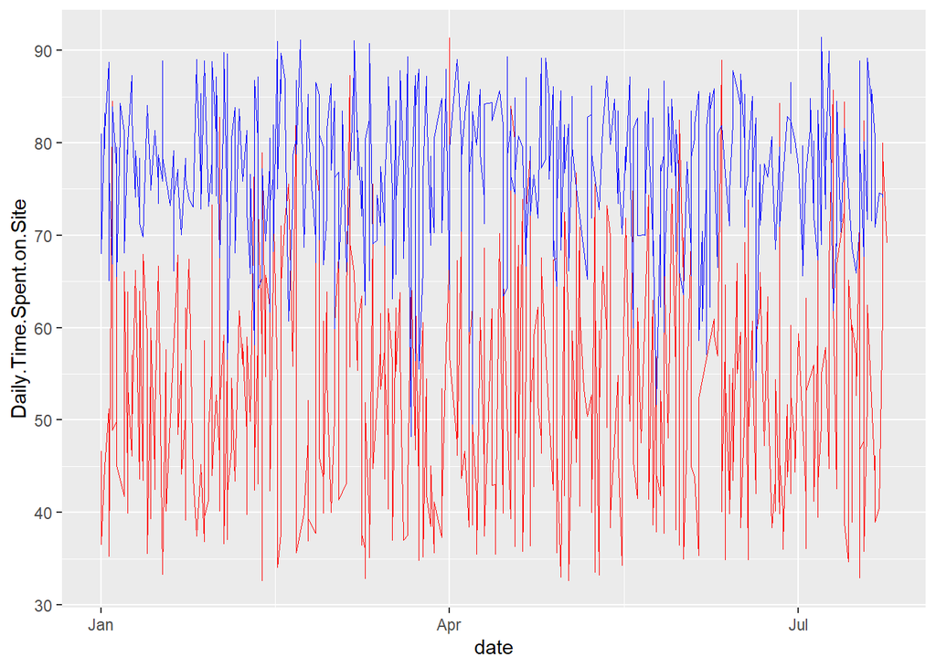

```r
a <- df[df$Clicked.on.Ad == "Yes",]
b = df[df$Clicked.on.Ad=="No",]
LGI_1 <- ggplot() + geom_line(aes(y=Daily.Time.Spent.on.Site, x=date),
                            size=0.1,
                            colour="red",
                            data = a) +
  geom_line(aes(y=Daily.Time.Spent.on.Site, x=date),
            size=0.1,
            colour="blue",
            data = b)

LGI_1
```

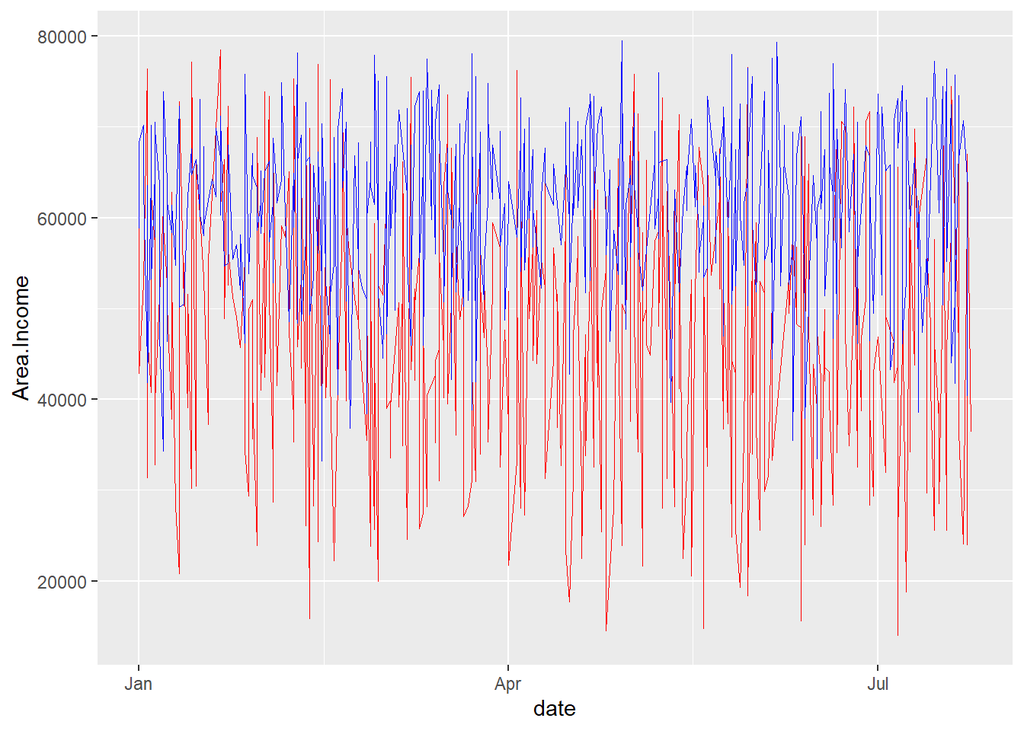

```r
LGI_1 <- ggplot() + geom_line(aes(y=Area.Income, x=date),
                            size=0.1,
                            colour="red",
                            data = a) +
  geom_line(aes(y=Area.Income, x=date),
            size=0.1,
            colour="blue",
            data = b)

LGI_1
```

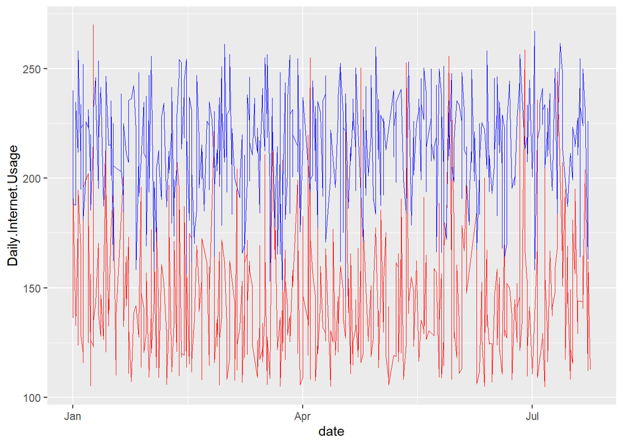

```r
LGI_1 <- ggplot() + geom_line(aes(y=Daily.Internet.Usage, x=date),
                            size=0.1,
                            colour="red",
                            data = a) +
  geom_line(aes(y=Daily.Internet.Usage, x=date),
            size=0.1,
            colour="blue",
            data = b)

LGI_1
```

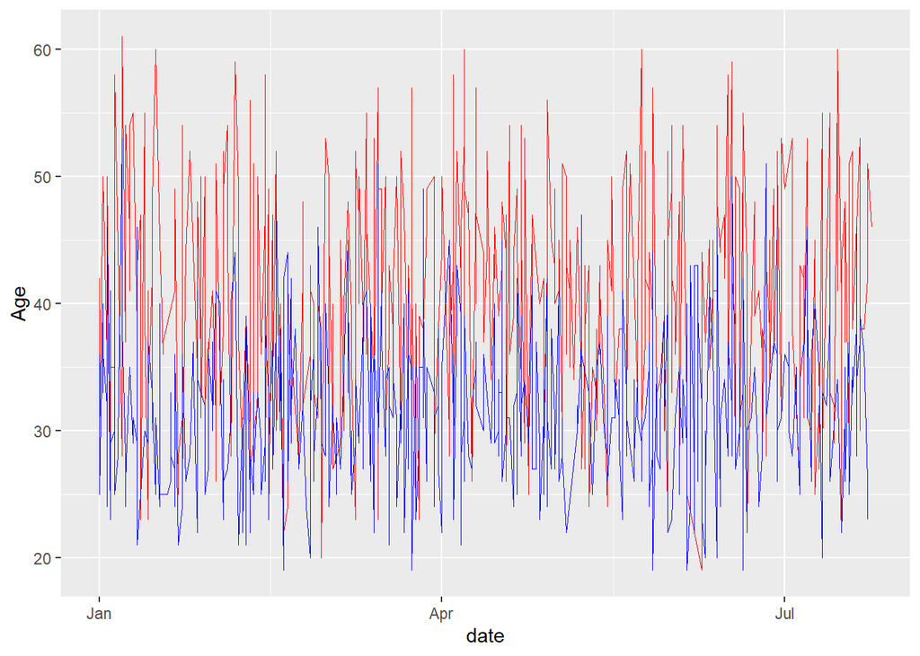

```r
LGI_1 <- ggplot() + geom_line(aes(y=Age, x=date),
                            size=0.1,
                            colour="red",
                            data = a) +
  geom_line(aes(y=Age, x=date),
            size=0.1,
            colour="blue",
            data = b)

LGI_1
```